# One question, start to finish

PCB 6455 / BSC 4933: Biometry | Lecture 22

Dr. Brian Maitner

## Today’s agenda

One question, **start to finish**, on data you have not seen:

1. Ask the question
2. Look at the data
3. Choose the distribution
4. Choose the deterministic function
5. Fit, and check the fit worked
6. Compare models
7. Check the best model against the data
8. Put intervals on the answer, draw it, and say it in biology

Then **your turn**: the same eight steps, on a second question.

Type and run on a code block: type it into your script and run it. Code without the label is there to watch.

## The story so far

- We have learned each piece **separately**: distributions, functions, fitting, comparing, checking, intervals
- Each lecture used a dataset chosen to show **one** piece
- **Today:** all the pieces, in order, on one new dataset

# The question and the data

## Step 1: sponges on a mid-ocean ridge

- **The Charlie-Gibbs Fracture Zone**: a break in the Mid-Atlantic Ridge, about 52° N, 560 to 2,970 m deep
- In 2018, five ROV dives filmed the seafloor; every **50 m section** was scored for substrate and the animals in view
- **Sponges** filter food from the water, and most must **attach to something hard**

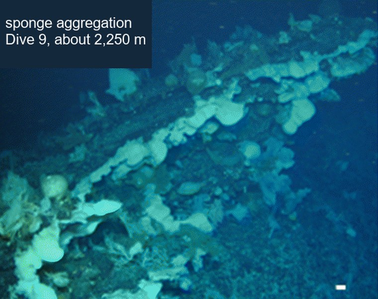

Photo: Keogh et al. 2022, CC BY 4.0, cropped and relabeled

**The question:** are sponges denser on hard substrate than on soft sediment? And does depth matter once substrate is accounted for?

**The prediction:** more on bedrock and boulders, fewer on sand and gravel.

## What the substrates look like

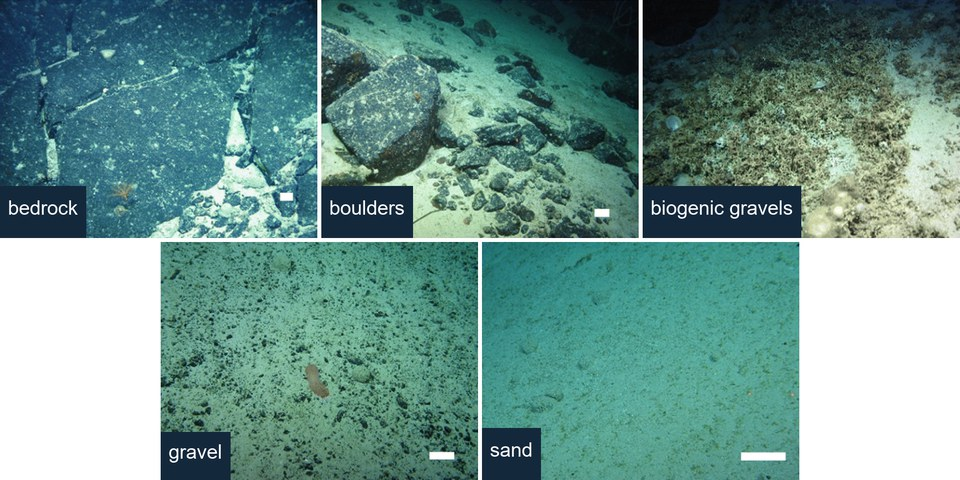

All from these dives, at 2,000 to 2,500 m. White bars are 100 mm.

Photos on this and other slides: Keogh, Command, Edinger, Georgiopoulou and Robert (2022), *Marine Biodiversity* 52:55, [doi:10.1007/s12526-022-01285-1](https://doi.org/10.1007/s12526-022-01285-1), [CC BY 4.0](https://creativecommons.org/licenses/by/4.0/); cropped, panel letters removed, and relabeled

## Get set up

```r
library(bbmle)
library(emdbook)        # for the zero-inflated negative binomial, later
library(biometrydata)
library(ggplot2)        # for the figure, later

# the original column names are long and mangled: rename the ones we need
rov <- data.frame(dive = tosca_rov$Dive.no,
                  depth = tosca_rov$Depth.water..m.,
                  substrate = tosca_rov$Substrate,
                  fov = tosca_rov$FOV.camera..m.,       # camera width, m
                  sponges = tosca_rov$Porifera....,
                  corals = tosca_rov$Cnidaria....)      # all cnidarians, mostly corals

rov <- rov[!is.na(rov$fov), ]        # sections with no camera width
rov$area <- 50 * rov$fov             # seafloor seen: 50 m long, fov wide
```

**Check:** 729 sections, down from 749.

## Step 2: look at the data

```r
table(rov$substrate)

mean(rov$sponges == 0)                                 # fraction with none
c(mean = mean(rov$sponges), variance = var(rov$sponges))

rov$density <- 100 * rov$sponges / rov$area           # per 100 m2
tapply(rov$density, rov$substrate, median)
```

**Check:** 13% of sections have no sponges. The variance is about 206 times the mean. Median density: 41.2 per 100 m² on bedrock, 4.4 on sand.

**Think:** why look at the variance against the mean, and at how many zeros there are, before fitting anything?

## What the data look like

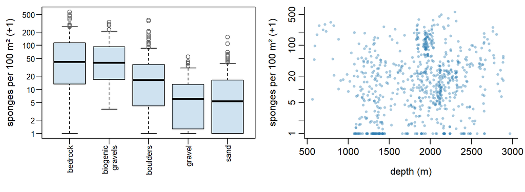

Left: denser on bedrock and biogenic gravels. Right: depth, by itself, shows no clear pattern.

# Building the model

## Step 3: which distribution?

| What we know | Points to |
| --- | --- |
| whole-number counts, no upper limit | Poisson or negative binomial |
| variance about 206 times the mean | **negative binomial** |
| 13% zeros | perhaps **zero-inflated**? |

A **zero-inflated** distribution has two kinds of zero: places where there could **never** be any, and places where there happened to be none.

A zero-inflated model says some places are truly empty, on top of the places that are empty by chance.

## Count, or density?

Two possible responses:

| Response | For | Against |
| --- | --- | --- |
| **count** | whole numbers: Poisson, negative binomial | not comparable: sections saw 96 to 929 m² |
| **density** (count per 100 m²) | comparable across sections | not whole numbers; 1 in 100 m² looks as sure as 10 in 1,000 m² |

**Both:** ask the question about density, but model the count, with

$$\mu = \text{density} \times \frac{\text{area}}{100}$$

Model the density, and let each section’s area scale it to an expected count. The count keeps its distribution, and big sections count for more.

## Step 3: fit three distributions

```r
# one density everywhere, three ways the counts could scatter around it
m_pois <- mle2(sponges ~ dpois(lambda = exp(log_d) * area / 100),
               start = list(log_d = 0), data = rov)
m_nb   <- mle2(sponges ~ dnbinom(mu = exp(log_d) * area / 100, size = exp(log_k)),
               start = list(log_d = 0, log_k = 0), data = rov)
m_zinb <- mle2(sponges ~ dzinbinom(mu = exp(log_d) * area / 100, size = exp(log_k),
                                   zprob = plogis(logit_z)),
               start = list(log_d = 0, log_k = 0, logit_z = -2), data = rov)
AICtab(m_pois, m_nb, m_zinb)
```

**Check:** the negative binomial beats the Poisson by **111,088** AIC units. Zero inflation adds nothing: 1.9 units **worse**.

## Step 4: the deterministic part

Four candidate models for the **density**, all negative binomial:

| Model | log density = | The idea |
| --- | --- | --- |
| `m_nb` | $a$ | one density everywhere |
| `m_sub` | $a_{\text{substrate}}$ | each substrate has its own |
| `m_depth` | $a + b \cdot \text{depth}$ | changes with depth |
| `m_both` | $a_{\text{substrate}} + b \cdot \text{depth}$ | both |

Depth in **km from 1,500 m**: centered and rescaled (Lecture 20), so $a$ is the density at 1,500 m and $b$ the change per km.

## Step 4: fit them

```r
rov$depth_km <- (rov$depth - 1500) / 1000

m_sub <- mle2(sponges ~ dnbinom(mu = exp(log_d) * area / 100, size = exp(log_k)),
              start = list(log_d = 0, log_k = 0),
              parameters = list(log_d ~ substrate - 1), data = rov)

m_depth <- mle2(sponges ~ dnbinom(mu = exp(log_d + b * depth_km) * area / 100,
                                  size = exp(log_k)),
                start = list(log_d = 0, b = 0, log_k = 0), data = rov)

m_both <- mle2(sponges ~ dnbinom(mu = exp(log_d + b * depth_km) * area / 100,
                                 size = exp(log_k)),
               start = list(log_d = 0, b = 0, log_k = 0),
               parameters = list(log_d ~ substrate - 1), data = rov)
```

`parameters = list(log_d ~ substrate - 1)`: one `log_d` **per substrate**. The `- 1` gives each substrate its own value, rather than differences from the first.

## Step 5: did the fits work?

```r
m_both@details$convergence              # 0 is good

# a second start, far from the first: does it find the same bottom?
m_both_2 <- update(m_both, start = list(log_d = 3, b = -1, log_k = 1))
c(m_both@min, m_both_2@min)
```

**Check:** convergence 0, and both starts reach an NLL of 3,640.15.

# Comparing and checking

## Step 6: compare

```r
AICtab(m_nb, m_sub, m_depth, m_both, weights = TRUE)
exp(coef(m_both))
```

**Check:** `m_both` is best, by 16.5 over `m_sub`. Depth alone is no better than nothing (0.4 units).

|  | bedrock | biogenic gravels | boulders | gravel | sand |
| --- | --- | --- | --- | --- | --- |
| sponges per 100 m², at 1,500 m | 61 | 98 | 26 | 6.9 | 9.1 |

And 1.70 times as dense for every km deeper.

## Step 7: does the best model look like the data?

The fraction of sections with **no sponges**, by substrate, real versus 1,000 fakes:

```r
set.seed(7)
mu_hat <- predict(m_both)                    # the fitted mean, every section
k_hat <- exp(coef(m_both)["log_k"])

fake_zeros <- replicate(1000, {
  fake <- rnbinom(nrow(rov), mu = mu_hat, size = k_hat)
  tapply(fake == 0, rov$substrate, mean)
})

cbind(observed = tapply(rov$sponges == 0, rov$substrate, mean),
      lower = apply(fake_zeros, 1, quantile, 0.025),
      upper = apply(fake_zeros, 1, quantile, 0.975))
```

**Check:** sand, 26% observed against 9% to 20% simulated.

## Too many empty sections

|  | observed | simulated, 95% |
| --- | --- | --- |
| bedrock | 3% | 3% to 9% |
| biogenic gravels | 0% | 0% to 13% |
| **boulders** | **13%** | 4% to 12% |
| **gravel** | **25%** | 10% to 25% |
| **sand** | **26%** | 9% to 20% |

Sand is well above its range, boulders just above, gravel at the very top.

Why? **Loose sediment** gives sponges nothing to settle on, so it can be **truly empty**. Boulder fields have sediment between the rocks (look back at the photo).

The check found something AIC could not: the best model was wrong in one particular place, and the biology said why.

## Step 7: let sediment be empty

```r
rov$sediment <- as.numeric(rov$substrate %in% c("sand", "gravel", "boulders"))

# the on/off switch: sediment is 0 or 1, so sediment * plogis(logit_z) is 0
# (zero inflation off) on rock and plogis(logit_z) (on) on sediment
# start near m_both's estimates
m_zero <- mle2(sponges ~ dzinbinom(mu = exp(log_d + b * depth_km) * area / 100,
                                   size = exp(log_k), zprob = sediment * plogis(logit_z)),
               start = list(log_d = 3, b = 0.5, log_k = -0.7, logit_z = -2),
               parameters = list(log_d ~ substrate - 1), data = rov)

AICtab(m_both, m_zero)
plogis(coef(m_zero)["logit_z"])
```

**Check:** `m_zero` is better by **28.9**. About **13%** of sand, gravel and boulder sections are truly empty.

# The answer

## Step 8: intervals, by the recipe

```r
set.seed(22)
draws <- MASS::mvrnorm(1000, mu = coef(m_zero), Sigma = vcov(m_zero))
colnames(draws)

# how many times denser on bedrock than on sand (where sponges can settle)
quantile(exp(draws[, "log_d.substratebedrock"] - draws[, "log_d.substratesand"]),
         c(0.025, 0.975))

# how many times denser for every km deeper
quantile(exp(draws[, "b"]), c(0.025, 0.975))

# the fraction of sediment sections that are truly empty
quantile(plogis(draws[, "logit_z"]), c(0.025, 0.975))
```

**Check:** 4.4 to 7.6; 1.22 to 1.90; 9% to 18%.

## Step 8: a band for the figure

Lecture 21’s band, with one new line: each grid point picks its own substrate’s parameter.

```r
grid <- expand.grid(depth = seq(900, 2900, by = 50), substrate = c("bedrock", "sand"))
grid$depth_km <- (grid$depth - 1500) / 1000
col_d <- paste0("log_d.substrate", grid$substrate)     # the new line

# one row per draw, one column per grid point
curves <- matrix(NA, nrow = 1000, ncol = nrow(grid))
for (i in 1:1000) {
  curves[i, ] <- exp(draws[i, col_d] + draws[i, "b"] * grid$depth_km)
}
grid$lower <- apply(curves, 2, quantile, 0.025)        # the middle 95%
grid$upper <- apply(curves, 2, quantile, 0.975)
grid$density <- exp(coef(m_zero)[col_d] + coef(m_zero)["b"] * grid$depth_km)
```

**Check:** bedrock at 1,500 m, 64 sponges per 100 m² (54 to 76).

## Step 8: draw it

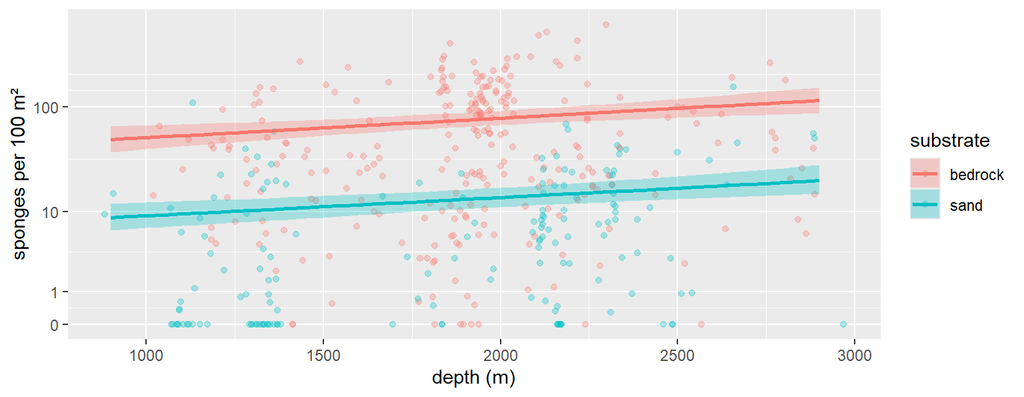

```r
ggplot(grid, aes(x = depth, y = density, color = substrate, fill = substrate)) +
  geom_point(data = rov[rov$substrate %in% c("bedrock", "sand"), ], alpha = 0.3) +
  geom_ribbon(aes(ymin = lower, ymax = upper), alpha = 0.3, color = NA) +
  geom_line(linewidth = 1) +
  scale_y_continuous(trans = "log1p", breaks = c(0, 1, 10, 100, 1000)) +  # log axis, allows 0
  labs(x = "depth (m)", y = "sponges per 100 m²")
```

## The answer, in biology

On the Charlie-Gibbs Fracture Zone:

- Where sponges can settle, they are about **6 times as dense on bedrock as on sand** (4.4 to 7.6)
- About **13% of sections on sand, gravel or boulders have no sponges at all** (9% to 18%)
- On the same substrate, density rises about **1.5 times per km deeper** (1.22 to 1.90)

The prediction holds, and the model found a second part of the story: **some patches with sediment are empty**, not just sparse.

## What this analysis cannot tell us

- **Five dives.** Neighboring sections on one dive are alike; a model with a separate density per dive fits better by 83 AIC units. Our intervals are too narrow
- **Observational.** Substrate and depth go together; neither was assigned
- **“Sponges” is a phylum.** Different species may respond differently

Every analysis has limits. Saying what they are is part of the answer, not an admission of failure.

# Your turn: corals

## Your turn: the same eight steps

**Corals** also feed on particles in the water, and many attach to hard substrate. Cold-water corals also depend on temperature, which falls with depth. (`corals` is shorthand: the column counts all cnidarians, but at least 79 of the 116 cnidarian morphospecies on these dives are corals.)

```r
c_nb <- mle2(corals ~ dnbinom(mu = exp(log_d) * area / 100, size = exp(log_k)),
             start = list(log_d = 0, log_k = 0), data = rov)

# c_sub, c_depth and c_both go here: the sponge models, with corals in place
# of sponges (hint: Step 4's slide)

# compare the four with AICtab() here
```

**Before you fit:** predict which model wins.

**Check:** `c_both` is best, and `c_depth` beats `c_sub` by 87 units.

## Your turn: how much does depth matter?

```r
set.seed(23)
# 1,000 draws from c_both go here (hint: Step 8's slide)

# how many times as dense for every km deeper, with its interval, goes here
```

**Check:** about **0.08 times** as dense per km deeper (0.06 to 0.11): about **92% fewer** corals for every km.

Now say it in biology, in one sentence, with the interval.

## Same workflow, different answers

|  | Sponges | Corals |
| --- | --- | --- |
| best model | substrate + depth, zeros on sediment | substrate + depth |
| bedrock vs sand | 5.7 times as dense | 5.3 times as dense |
| per km deeper | **1.5 times as dense** | **92% fewer** |
| which matters more | substrate | depth |

Two suspension feeders, on the same ridge, filmed on the same dives, with opposite responses to depth.

Photos: Keogh et al. 2022, CC BY 4.0, cropped and relabeled

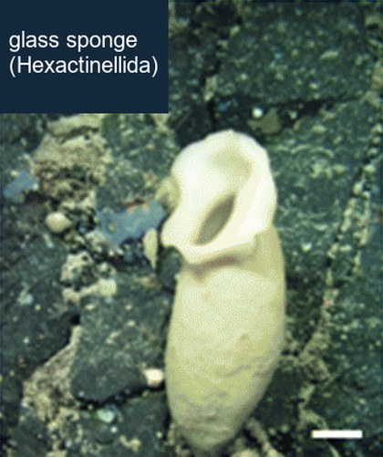

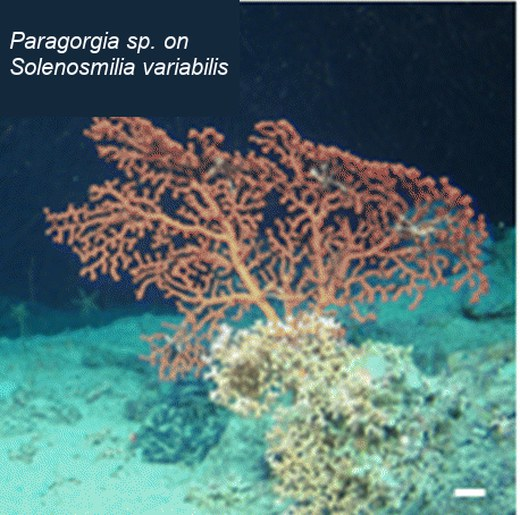

# Wrapping up

## The workflow, with its tools

| Step | Tools |
| --- | --- |
| 1. ask the question | a sentence and a prediction, before the data |
| 2. look at the data | `table()`, `tapply()`, plots: sizes, spread, zeros |
| 3. choose the distribution | AIC across distributions (Lecture 18) |
| 4. choose the deterministic part | `parameters =`, centering, rescaling (Lecture 20) |
| 5. check the fit worked | `convergence`, a second start (Lecture 19) |
| 6. compare models | `AICtab()`, `anova()` (Lecture 18) |
| 7. check against the data | simulate from the fit (Lecture 19) |
| 8. intervals, in biology | the recipe, `confint()`, a band (Lecture 21); `ggplot()` |

## Before next class

Read Bolker **9.1 to 9.2**

**Assignment 3** is due **Friday, November 6**

Next time: **general linear models**, `lm()`, and how they relate to everything so far